# Final Paper

STOR 320.01 Group 12

April 28, 2023

# INTRODUCTION

A police officer’s most basic duties are to ensure the safety of citizens through enforcement of the law and prevention of crime and civil disorder. However, there can be many factors such as lack of training, lack of resources, or personal biases that can prevent a police officer or police station from fulfilling these fundamental principles. As citizens of diverse communities, it is important that we feel protected by our police systems. The actions being taken by police systems should be unbiased and purposeful. Our group analyzed data from police killings in the United States from January 2015 to June 2015. Our goal with choosing this data set was to gain insight into the patterns–if any–of police killings in the U.S. during this time. Our first research question focuses on location visualization: what is the geographic distribution of police killings on a federal and state level. This question goes deeper by visualizing certain state’s killings in comparison to poverty levels of that state. Our second research question wonders whether we are able to predict whether an individual killed was unarmed, depending on other known factors about the deceased individual.

When determining our first analysis question, we believed it was important to begin by looking at the federal distribution of police killings to determine if there were certain states or regions in the United States that seemed to have higher rates of police killings. However, it is important to note that states like California, New York and Texas have significantly higher populations which could potentially skew the conclusions drawn. Therefore we made sure to consider this factor when we were determining rates. By accounting for population, this allowed us to see if there were states with higher rates of police killings by population. This information is valuable because it could identify problem areas in the United States that are afflicted with higher rates of police killings. This information can allow for the implementation of greater training and government intervention in certain states. Answering this question could also help Americans, or young adults, identify areas that are plagued by high rates of police killings which may indicate that they are more prone to violence and crime. We then decided to analyze police killings in relation to poverty levels for three specific states: NC, CA, and TX. Our goal was to see if there are any trends among poverty levels and where police killings occur, and if so to identify these areas. This was important because we wanted to examine if socioeconomic factors affect the amount of police killings that occur in an area.

While exploring our data set, the percentage of police killings that involved unarmed individuals struck us as interesting and worth investigating. About 22% of all police shootings in the United States between January 2015 and June 2015 were of unarmed individuals. Historically, there has been a trend of American police officers using excessive force and violence against citizens. Police aggression has long been a political focal point as there have been many national news cases of U.S. citizens who have been unfairly killed by police and many more that go uninvestigated. Our group chose to further investigate unarmed killings because these represent times when a police killing is deemed unfair. Our data set does not include a description of the killing, so there could be extenuating circumstances where a police officer was in imminent danger or the subject was attempting to flee after the infliction of a serious crime. However, with the rapid implementation of non-fatal weapons, our society views unarmed killings as unnecessary. Our question strives to understand the patterns of unarmed killings by investigating the relationship between identifying factors about a deceased individual and whether that individual was unarmed when they were killed. Through various modeling techniques, we attempt to predict whether an individual was armed or unarmed based on known variables provided in our data set, which will be specified later. This information is extremely important because ideally, there should be no pattern for prediction of whether an individual is unarmed or not. A pattern in unarmed kills would mean that a person could be at risk for being unfairly killed based on certain aspects about them or where they live. If there are variables that allow for prediction of unarmed killings, then an owner of this data set would use this information to inspire more research to be done about why these variables lead to increased unarmed killings. American citizens would be extremely interested in the findings of this question because they want to feel safe. If patterns are found in unarmed killings, citizens deserve to know what variables make them more likely to be the victim of an unarmed police killing.

# DATA

We found our dataset, titled “Police Killings”, on data.world. This data set was put together by a journalism site called FiveThirtyEight who combined data collected by The Guardian with census data from the American Community Survey conducted by the United States government. The data set includes information about police killings in the United States between January and June of 2015. The Guardian’s data regarding police killings was gathered from media coverage, police reports, and reporting efforts from publicly available labs. This data was then fact-checked by The Guardian and later merged with census data by FiveThirtyEight. This dataset contains 467 entries, each entry representing a unique police killing. This group of 467 individuals is a sample of the population of all individuals who were killed by the police in the United States.

Each entry has been characterized by 35 variables ranging from information about the individual, to location information, to information about the tract and county the deceased individual was from. However, not all of the 35 variables were relevant to our analysis of the information. A portion of our data cleaning process included removing duplicate or irrelevant columns. When determining what columns to keep, our group knew we needed variables that could be grouped/measured. An example of a variable our group found irrelevant was the State’s FIPS code. This column of information is more organizational than helpful to understanding the data. The variables that our group decided were most important and which will be used in our research questions include:

- Age of the individual at the time of their death
- The individual’s gender
  - Male
  - Female
- Race/Ethnicity of the individual
  - White
  - Black
  - Hispanic
  - Asian
  - Native American
  - Unknown.
- Cause of death
  - Gunshot
  - Struck by vehicle
  - Death in custody
  - Taser
  - Unknown
- Population of the tract
- Proportion of the tract that was white
- Proportion of the tract that was black
- Proportion of the track that was hispanic
- Personal income of the tract
- Household income of the tract
- Poverty rate of the tract
- Unemployment rate of the tract
- Latitude of the police killing
- Longitude of the police killing
- Proportion of the tract with a Bachelor’s degree or higher.

The following table provides an overview of some of the most relevant variables that we analyzed throughout our follow up questions.

| name | age | raceethnicity | pop | armed | share_white | share_black | share_hispanic | p_income |
| --- | --- | --- | --- | --- | --- | --- | --- | --- |
| A’donte Washington | 16 | Black | 3779 | No | 60.5 | 30.5 | 5.6 | 28375 |
| Aaron Rutledge | 27 | White | 2769 | No | 53.8 | 36.2 | 0.5 | 14678 |
| Aaron Siler | 26 | White | 4079 | No | 73.8 | 7.7 | 16.8 | 25286 |
| Aaron Valdez | 25 | Hispanic/Latino | 4343 | Firearm | 1.2 | 0.6 | 98.8 | 17194 |
| Adam Jovicic | 29 | White | 6809 | No | 92.5 | 1.4 | 1.7 | 33954 |
| Adam Reinhart | 29 | White | 4682 | No | 7.0 | 7.7 | 79.0 | 15523 |
| Adrian Hernandez | 22 | Hispanic/Latino | 5027 | Firearm | 50.8 | 0.3 | 44.2 | 25949 |
| Adrian Solis | 35 | Hispanic/Latino | 5238 | Non-lethal firearm | 8.6 | 0.2 | 84.1 | 25043 |
| Alan Alverson | 44 | White | 4832 | Firearm | 14.6 | 17.7 | 66.3 | 16778 |
| Alan James | 31 | White | 3795 | Other | 63.6 | 7.7 | 26.5 | 22005 |

The following model is an interactive map displaying the geographic distribution of police killings, organizing points by color. Unarmed individuals that were killed are marked with purple points and armed individuals that were killed are marked with yellow points. This map offers some insight into both research questions by showcasing some geographical trends as well as highlighting the relatively high rates of unarmed police killings.

[interactive chart not shown]

Our first research question investigated the location of police killings in the first months of 2015 across the United States as well as on a state-scale. However, we wanted to visualize the location of these killings in combination with the poverty rates in those same areas. However, our police killings data set only included poverty rates at a tract-level scale. Because tracts are purposefully small to accurately describe a community, visualizing all of the tracts of one state on a map would not be aesthetically appealing. The lines between tracts would be extremely small and it would be difficult to distinguish between each one. We decided our state maps should be broken up by county so viewers could easily differentiate between them. So, we had to turn to outside data sources to obtain poverty rates of counties in Texas, California, and North Carolina. The data we used for these poverty rates came from the 2015 Census Bureau and contains estimates of poverty and income for all 50 states. Additionally, in order to limit confounding variables, like population size, that affect trends, state population data from the U.S. Census Bureau was used account for population size differences and to better understand the rate of police killings relative to where they occur.

# RESULTS

For our first research question we decided to look at the federal distribution of police killings to identify any areas that have a higher rate of police killings than average. First, we decided to create maps that helped visualize our data. On the left, we have the number of police killings in each state, from January to June 2015. On the right, we have the number of police killings in each state per million residents. Looking at our original graph it would be easy to assume that California and Texas have the highest rates of police killings, however when we account for the population of these states it is clear that this is not true. With the map that accounts for population size, we can see that it is actually Oklahoma that has the highest rates of police killings. During this time period, Oklahoma had 22 police killings which calculates to 5.63 individuals per million residents. This suggests that more research and investigation should be done into Oklahoma’s police departments and their training protocols. It is also important to consider that we are not getting the full picture by just looking at police killings; we would also need to consider interactions between police and residents where no violence took place to understand which areas truly need a larger focus in terms of government attention or training.

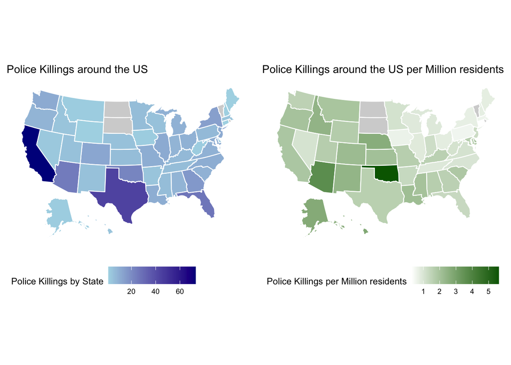

Next, we decided to examine locations of police killings in accordance with poverty levels by county. We decided to explore this relationship to see if areas with a lower socioeconomic status were more affected by police violence. We used county level poverty data from 2015 that was published by the Census Bureau. We decided to focus on 3 states: California, Texas, and North Carolina. We chose to evaluate California because it was the state with the largest amount of police killings and chose Texas because it had the largest amount of unarmed police killings. Finally, we decided to take a closer look at North Carolina because it is our home state and this data and research directly impacts our own communities. Additionally, we created a distinction between armed police killings and unarmed police killings in the maps. To do this we created a new variable in our dataset that assigned each incident with either “Yes” if armed, “No” if unarmed, and “Unknown or Disputed” for unknown or disputed cases.

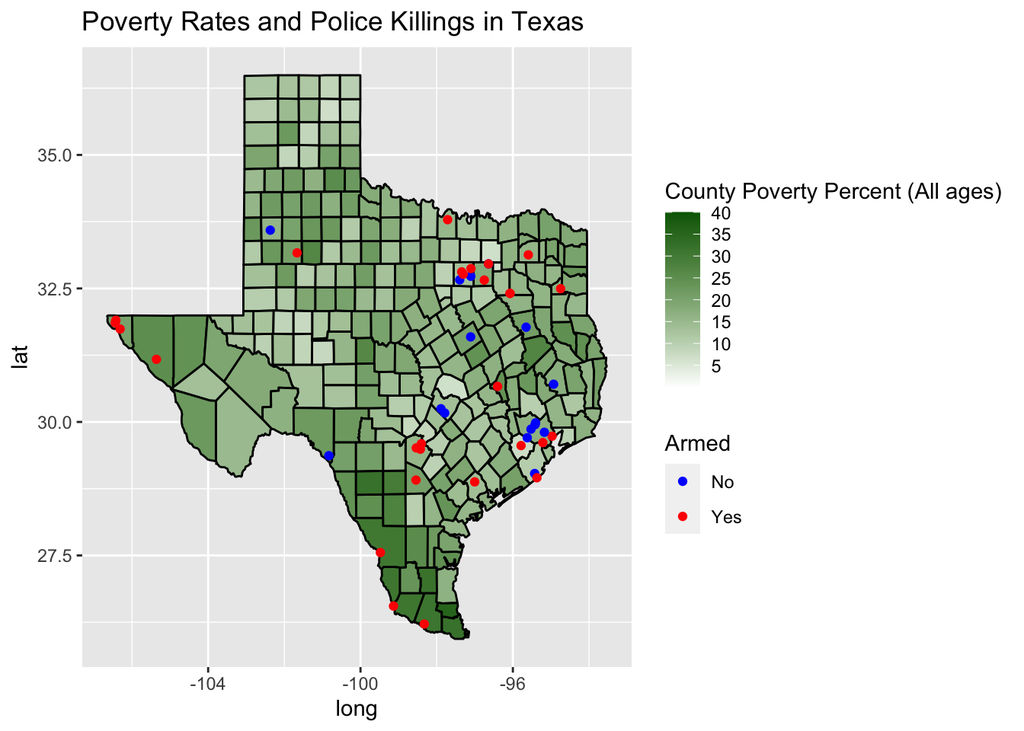

From the Texas plot, we can see that police killings in Texas occur most frequently in metropolitan areas. Specifically, Dallas and Houston have higher numbers of police killings. These areas generally have a wide range of income and poverty levels due to their diverse nature. This trend could be explained by higher populations in metropolitan areas or higher rates of crime in general. However, it should still be a focus to evaluate these areas and their police departments for further review. Outside of the main metropolitan areas, we noticed the string of mostly armed police killings around the U.S. border. These areas, specifically the Southeast border, have high levels of poverty. We can also see that there is a cluster of unarmed police killings in Harris County, which is where Houston is located. In Harris County, 5 out of the 7 individuals killed by the police were unarmed. Using this information, we can identify Harris County and the US - Mexico border as areas of interest where further information should be analyzed about the incidents and the respective police departments involved.

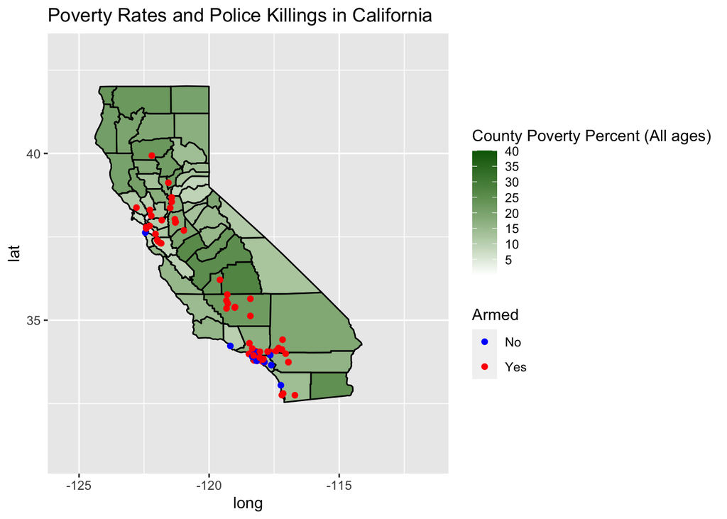

The California map does not follow all of the same trends that the Texas map does. Although the police killings are concentrated in metropolitan areas, like San Francisco and Los Angeles, there are also many incidents that take place across the Central California Valley. Similarly to Texas, these metropolitan areas have lower poverty levels, in comparison to the rural parts of the valley. One interesting trend that is seen from this map is that all of the unarmed killings occurred along the coastal metropolitan areas. If we look specifically at Los Angeles County 20 police killings took place during this time, 4 of which involved unarmed individuals. The LA area should be an important area of interest for further investigation, due to the concentration of police killings.

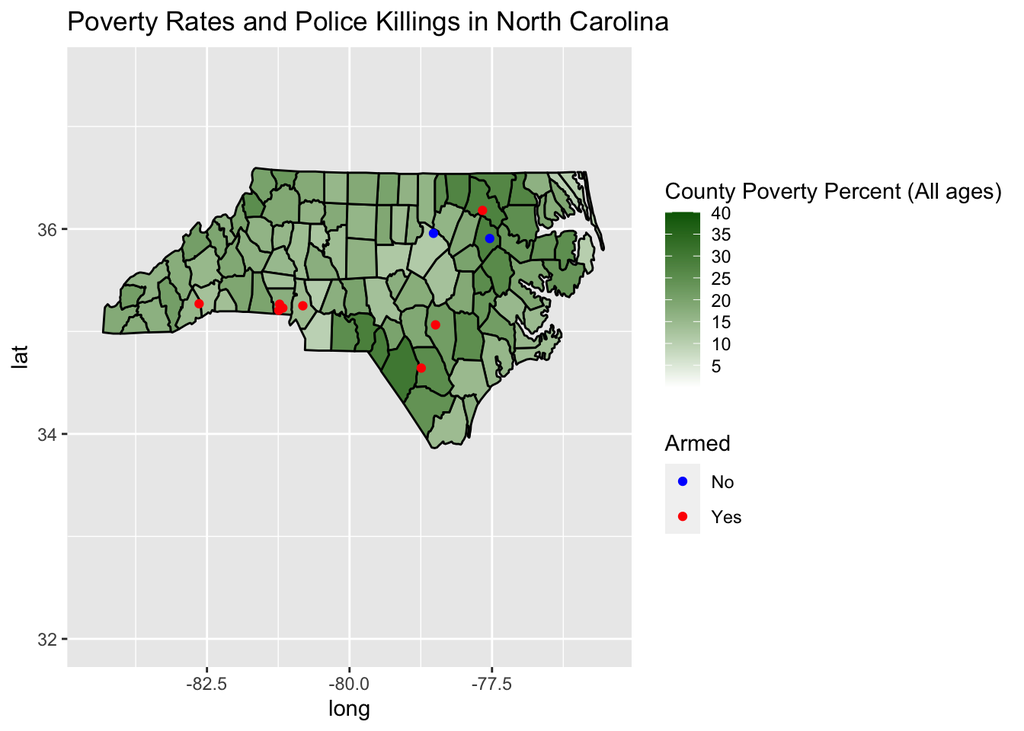

The last state that we chose to focus on was North Carolina. In North Carolina you can see a small cluster of points around the Charlotte Metropolitan area, with the rest of the incidents occurring in more rural communities. We observe again that there is not a visible relationship between county poverty levels and police killing occurrences, which is something that we saw across Texas and California as well. Through the use of maps we were able to observe trends that you would not be able to see through models or other methods. Although we were not able to identify a relationship between poverty and police killings, we were able to observe local level trends that were not originally clear. This tells us that looking at these incidents at a local-level, may be the best way to identify problems and present solutions.

Our second research question wonders whether we can predict if a deceased individual was armed or unarmed when they were killed, based upon known information about the tract they lived in and who they were. A tract is a small subdivision of a county, containing anywhere from 1,200 to 8,000 citizens. Tracts are given ID codes so that statistical observation can remain constant from year to year. It can be beneficial to use tract information over county information because tracts give a glimpse at trends within smaller communities. Our group decided it was best to answer this question using statistical models. Firstly, we had to narrow down the predictor variables we were going to use to guess our response variable. The response variable in our data set is a column called `armed_binary`. This column contains either a 0 or 1 with 0 meaning the individual was armed at the time of their death and 1 meaning they were unarmed. After removing repeated information and organizational columns, the variables we used in our prediction models were:

- Age
- Gender
- Race
- Cause of death
- Population of the tract
- Proportion of the tract that was White
- Proportion of the tract that was Black
- Proportion of the track that was Hispanic
- Personal income of the tract
- Household income of the tract
- Poverty rate of the tract
- Unemployment rate of the tract
- Proportion of the tract with a Bachelor’s degree or higher.

The data set police_killings5 contains the 13 predictor variables and our response variable. Our group decided to test seven different models. For five models, we utilized generalized linear regression. The first linear regression model uses all 13 predictor variables. The second model is empty, meaning it takes none of the variables into account when simulating the data; the model only uses the intercept. The third model uses all two-way interactions between the variables. From the summary of this model, we recorded the significant interactions to then use in the fourth model. For the fifth model, our group wondered if there was significance between the interaction of race and cause of death. To test the prediction accuracy of these models, we utilized cross validation. After cross validation, we were able to calculate the accuracy of our models by comparing the predicted classifications to the actual classifications of armed vs. unarmed. The sixth model our group created was a k-Nearest-Neighbors model that used the significant variables from model 4. The seventh model was also a k-Nearest Neighbors model that took all numeric predictor variables into account. To begin, we standardized the numeric variables of 13 original predictor variables. We left out race, gender, and cause of death because these are categorical variables. For both of these models, we found the optimal value for k by looping through k values 1 through 250 and measuring the accuracy of each one. For the model with the significant interactions the best k value was 12. For the model with all numeric predictor variables, the best k value was 21. We also used cross validation to measure the accuracy of these models.

Because our response variable is binary, this made it easy to assess the accuracy of each model. The classification of each model was measured against the actual classification of each individual. Additionally, it was important our group knew the specificity and sensitivity values of each model. These values are important when making decisions about the best model to use for prediction because it gives more detail about what the model is best at predicting. Higher values of each mean that the model is better at classification. The specificity of a model measures the percentage of true negative predictions. The sensitivity of a model measures the percentage of true positives.

| Model | Accuracy | Specificity | Sensitivity |
| --- | --- | --- | --- |
| All Variables | 0.775 | 0.997 | 0.000 |
| No Variables | 0.777 | 1.000 | 0.000 |
| All 2-Way Interactions | 0.634 | 0.744 | 0.248 |
| Significant 2-Way Interactions | 0.777 | 1.000 | 0.000 |
| Interaction between Race and Cause of Death | 0.768 | 0.986 | 0.010 |
| K-NN with Significant 2-Way Interactions | 0.775 | 0.989 | 0.030 |
| K-NN with No Race, Cause or Gender | 0.777 | 1.000 | 0.000 |

|  | Predicted Armed | Predicted Unarmed |
| --- | --- | --- |
| Armed | 0.7770419 | 0 |
| Unarmed | 0.2229581 | 0 |

This means that there are no variables in the police_killings5 data set that will help classify individuals as armed or unarmed. We can just as accurately classify individuals without knowing anything about them as we can when we have 13 variables worth of information. The percentage of individuals in our original data set that were armed was 77.7%.

# CONCLUSION

It is part of our duty as American citizens to hold our government accountable for its actions towards and for the public. Police officers and police stations must fulfill high standards because their work directly affects the daily lives of almost every citizen. It is important to continuously evaluate whether the systems that have been put in place benefit the public, or if there are issues that need to be addressed. Our purpose with analyzing police killings in the United States from January to June 2015 was to ensure that the killings recorded had no identifiable patterns as these often suggest unchecked injustice within the police system.

Our visualization question helped us determine there is no visual relationship between poverty and police killings. The percent poverty level did not appear to influence how many police killings occurred. This conclusion is extremely important to the public of the United States because citizens should not feel predisposed to police discipline because of the poverty rate of the areas where they live. However we did identify certain areas in Texas, California, and North Carolina that could benefit from further investigation. There were some areas on these state maps that showed clusters of police killings. Since the poverty rate did not appear to have influence over these clusters, further research would go into discovering what other factor(s) are contributing to these clusters.

From extensive modeling, our group concludes that there are no significant variables or combinations of variables in our police killings data set that make prediction of whether an individual was armed or unarmed more accurate. The model with the highest rate of classification accuracy was an empty model that takes no variables into account. This conclusion was unexpected, but we were happily surprised. Before modeling, our group believed that there would be an identifiable pattern in unarmed killings partly because there were so many characterizing variables. The United States police system is known to be flawed and in some aspects outdated and harmful. However, this conclusion could be reassuring to the general public because there is no type of person or place that is more likely to be killed while they are unarmed, it is random. It is important to note that our models and thus conclusion is based on half a year of data, and with access to a larger data set a better model to predict whether an individual is armed or not may be identifiable.

# REFERENCES

- Census Data: https://www.census.gov/data/datasets/2015/demo/saipe/2015-state-and-county.html
- Police Killings Data Set: https://data.world/fivethirtyeight/police-killings/workspace/file?filename=police_killings.csv
- Population Data: https://www.census.gov/data/tables/time-series/demo/popest/2010s-state-total.html